# 03 Compare rawnav data to the field data

This notebook provides a comparison between the rawnav data and the field data. The aim of this notebook is to validate the information in rawnav data and the processed data obtained from the `wamatarawnav` package. `wamatarawnav`package is developed for the WMATA Analysis of Fine-Grained Bus AVL to Evaluate Queue Jump Effectiveness study (Queue Jump Effectiveness study). Refer to *01 -Introduction to parsing rawnav data with `wmatarawnav`*, *02 - Relating rawnav data to other data sources with `wmatarawnav`*, and *04 - Trajectory decomposition at the stop zone* for a basic overview of the `wmatarawnav` package and its implementation for cleaning and processing rawnav data.

The field data was collected for the following queue jump locations on $7^{th}$, $8^{th}$, $9^{th}$, $14^{th}$, $15^{th}$, and $16^{th}$ July during the morning and evening peak hours (morning peak for some days and locations and evening peak for the others):

- 16th and U
- Georgia & Columbia
- Georgia & Irving
- Georgia & Piney Branch
- 11th & NY
- Irving & 16th

This notebook focuses on comparing the data from the *16th and U* and *Georgia and Columbia* queue jump stops for July 7<sup>th</sup>. We would extend this notebook to include field data for other dates and locations.

Rawnav data was obtained and processed for the dates on which field observation was carries out. We carried out high-level comparisons such as verifying the Bus IDs of the buses observed at the queue jump location match the Bus IDs observed in the rawnav data or the time when the rear door opens in the field matches the time from rawnav data. We also compared the processed data obtained from the `wmatarawnav` package on measures like "Dwell Time" with the field observed value. In addition to these, we categorized the bus trajectories observed in the field based on whether the bus stopped at the bus-stop and if the bus stopped at the signal downstream of the bus-stop. Note: all the queue jump location in this study are near-side thus the queue jump bus-stop is immediately followed by an intersection.

# Table of Contents

## Field data

Following table shows the data collection schedule for different queue jump locations.

| Queue Jump Location | Date (Day of week) | Time of Day | Bus Routes | Direction |
| --- | --- | --- | --- | --- |
| 16th & U | 7/7/2020 (Tue) and 7/14/2020 (Tue) | 4 PM to 6 PM | S1, S2, S4, and S9 | Northbound |
| Georgia & Columbia | 7/7/2020 (Tue) and 7/14/2020 (Tue) | 7 AM to 9 AM | 70 and 79 | Southbound |
| Georgia & Irving | 7/8/2020 (Wed) and 7/15/2020 (Wed) | 7 AM to 9 AM | 70 | Southbound |
| Georgia & Piney Branch | 7/9/2020 (Thu) and 7/16/2020 (Thu) | 7 AM to 9 AM | 70 and 79 | Southbound |
| 11th & NY | 7/8/2020 (Wed) and 7/15/2020 (Wed) | 4 PM to 6 PM | 64 and G8 | Northbound |
| Irving & 16th | 7/9/2020 (Thu) and 7/16/2020 (Thu) | 4 PM to 6 PM | D32, H1, H2, H3, H4, H8, and W47 | Eastbound |

We first read the field data and process it to ensure the data types of different fields are consistent. The following code chunk reads the field data and format the field data with some helper functions to assign correct data type to the columns.

```python
# Path to the field data
path_field_dir = r'C:\Users\abibeka\OneDrive - Kittelson & Associates, Inc\Documents\WMATA-AVL\Data' \
                 r'\field_rawnav_dat'
path_field_file = os.path.join(path_field_dir, 'WMATA AVL field obsv spreadsheet v.2.xlsx')
field_xlsx_wb = pd.ExcelFile(path_field_file) # Point to the excel file
field_dict = {}  # Store data for different queue jump locations in a dictionary.

# Rename the columns: New columns names are in snake_case
col_keep = ['Metrobus Route', 'Bus ID', "Today's Date", 'Signal Phase', 'Time Entered Stop Zone',
            'Time Left Stop Zone',
            'Front Door Open Time', 'Front Door Close Time', 'Rear Door Open Time', 'Rear Door Close Time',
            'Dwell Time',
            'Number of boardings', 'Number of alightings', 'Total Time at Intersection', 'Traffic Conditions',
            'Notes']

col_new_names = ['metrobus_route_field', 'bus_id_field', 'date_obs_field', 'signal_phase_field',
                 'time_entered_stop_zone_field','time_left_stop_zone_field',
                 'front_door_open_time_field', 'front_door_close_time_field', 'rear_door_open_time_field',
                 'rear_door_close_time_field','dwell_time_field','number_of_boarding_field',
                 'number_of_alightings_field', 'total_time_at_intersection_field', 'traffic_conditions_field',
                 'notes_field']
field_col_rename_map = {key: value for (key, value) in zip(col_keep, col_new_names)}

# Iterate over field data sheets. Read data and correct data types.
for sheet in field_xlsx_wb.sheet_names:
    dat = field_xlsx_wb.parse(sheet)
    dat = dat.loc[:, col_keep].rename(columns=field_col_rename_map)
    dat = correct_data_types(dat) # correct the data types using helper function correct_data_types
    field_dict[sheet] = dat
```

We have the following fields in the field data:

- metrobus_route_field: Metrobus route
- bus_id_field: Bus ID displayed on the bus
- date_obs_field: observation date
- signal_phase_field: signal phase upon arrival of bus: red or green
- time_entered_stop_zone_field: time entered stop zone. Stop zone starts at XX ft. from the bus stop and ends at XX ft. from the bus stop. update after checking with Adam.
- time_left_stop_zone_field: Time left stop zone. Stop zone starts at XX ft. from the bus stop and ends at XX ft. from the bus stop. update after checking with Adam.
- front_door_open_time_field: front door open timestamp
- front_door_close_time_field: front door close timestamp
- rear_door_open_time_field: rear door open timestamp
- rear_door_close_time_field: rear door close timestamp
- dwell_time_field: rear_door_close_time_field -rear_door_open_time_field. update after checking with Adam.
- number_of_boarding_field: number of boardings
- number_of_alightings_field: number of alighting
- total_time_at_intersection_field: It is the total time in seconds from arrival to departure
- traffic_conditions_field: Free-flowing, moderate, or congested? update after checking with Adam.
- notes_field: notes about whether bus did not stop or if the bus didn't have route information.

We would now only keep the data for *16th and U* and *Georgia and Columbia* segments. Following cells show the processed field data for these two locations.

```python
field_qjump_16_U = field_dict['16th & U']
field_qjump_16_U
```

|  | metrobus_route_field | bus_id_field | date_obs_field | signal_phase_field | time_entered_stop_zone_field | time_left_stop_zone_field | front_door_open_time_field | front_door_close_time_field | rear_door_open_time_field | rear_door_close_time_field | dwell_time_field | number_of_boarding_field | number_of_alightings_field | total_time_at_intersection_field | traffic_conditions_field | notes_field |
| --- | --- | --- | --- | --- | --- | --- | --- | --- | --- | --- | --- | --- | --- | --- | --- | --- |
| 0 | S4 | 7365 | 2020-07-07 | Green | 2020-07-07 16:01:37 | 2020-07-07 04:02:03 | NaT | NaT | 2020-07-07 04:01:44 | 2020-07-07 04:01:57 | 00:00:13 | 3 | 0 | 00:00:26 | free-flowing | nan |
| 1 | S2 | 7252 | 2020-07-07 | Green | 2020-07-07 16:10:52 | 2020-07-07 04:12:19 | NaT | NaT | 2020-07-07 04:10:59 | 2020-07-07 04:11:17 | 00:00:18 | 4 | 0 | 00:01:27 | free-flowing | This is likely an S2, but the sign on the rear... |
| 2 | S4 | 5467 | 2020-07-07 | Green | 2020-07-07 16:25:37 | 2020-07-07 04:25:55 | NaT | NaT | 2020-07-07 04:25:43 | 2020-07-07 04:25:48 | 00:00:05 | 1 | 1 | 00:00:18 | free-flowing | nan |
| 3 | S2 | 7374 | 2020-07-07 | Green | 2020-07-07 16:38:24 | 2020-07-07 04:38:47 | NaT | NaT | 2020-07-07 04:38:32 | 2020-07-07 04:38:43 | 00:00:11 | 2 | 0 | 00:00:23 | free-flowing | nan |
| 4 | S4 | 6434 | 2020-07-07 | Green | 2020-07-07 16:51:05 | 2020-07-07 04:51:28 | NaT | NaT | 2020-07-07 04:51:13 | 2020-07-07 04:51:21 | 00:00:08 | 1 | 0 | 00:00:23 | moderate | nan |
| 5 | S2 | 7373 | 2020-07-07 | Green | 2020-07-07 17:00:08 | 2020-07-07 05:00:41 | NaT | NaT | 2020-07-07 05:00:16 | 2020-07-07 05:00:34 | 00:00:18 | 2 | 0 | 00:00:33 | free-flowing | nan |
| 6 | S4 | 6443 | 2020-07-07 | Green | 2020-07-07 17:11:29 | 2020-07-07 05:12:55 | NaT | NaT | 2020-07-07 05:11:36 | 2020-07-07 05:11:57 | 00:00:21 | 2 | 1 | 00:01:24 | free-flowing | nan |
| 7 | S2 | 7350 | 2020-07-07 | Green | 2020-07-07 17:25:55 | 2020-07-07 05:27:35 | NaT | NaT | 2020-07-07 05:26:05 | 2020-07-07 05:26:25 | 00:00:20 | 5 | 2 | 00:01:40 | free-flowing | nan |
| 8 | S4 | 4469 | 2020-07-07 | Green | 2020-07-07 17:38:39 | 2020-07-07 05:39:13 | NaT | NaT | 2020-07-07 05:38:51 | 2020-07-07 05:39:03 | 00:00:12 | 2 | 0 | 00:00:34 | moderate | nan |
| 9 | S4 | 7249 | 2020-07-07 | Green | 2020-07-07 18:03:00 | 2020-07-07 06:04:15 | NaT | NaT | 2020-07-07 06:03:13 | 2020-07-07 06:03:44 | 00:00:31 | 8 | 1 | 00:01:15 | moderate | An S2 passed by, but did not stop, at 5:59 |

```python
field_qjump_georgia_columbia = field_dict['Georgia & Columbia']
field_qjump_georgia_columbia
```

|  | metrobus_route_field | bus_id_field | date_obs_field | signal_phase_field | time_entered_stop_zone_field | time_left_stop_zone_field | front_door_open_time_field | front_door_close_time_field | rear_door_open_time_field | rear_door_close_time_field | dwell_time_field | number_of_boarding_field | number_of_alightings_field | total_time_at_intersection_field | traffic_conditions_field | notes_field |
| --- | --- | --- | --- | --- | --- | --- | --- | --- | --- | --- | --- | --- | --- | --- | --- | --- |
| 0 | 70 | 7270 | 2020-07-07 | Green | 2020-07-07 07:01:57 | 2020-07-07 07:02:00 | NaT | NaT | NaT | NaT | 00:00:00 | 0 | 0 | 00:00:03 | Free-Flowing | Did not stop |
| 1 | 79 | 6040 | 2020-07-07 | Green | 2020-07-07 07:13:41 | 2020-07-07 07:14:15 | 2020-07-07 07:13:49 | 2020-07-07 07:14:10 | 2020-07-07 07:13:49 | 2020-07-07 07:14:10 | 00:00:21 | 4 | 3 | 00:00:44 | Free-Flowing | nan |
| 2 | 70 | 7350 | 2020-07-07 | Green | 2020-07-07 07:24:36 | 2020-07-07 07:25:31 | NaT | NaT | 2020-07-07 07:24:44 | 2020-07-07 07:24:58 | 00:00:14 | 6 | 0 | 00:00:55 | Free-Flowing | nan |
| 3 | 79 | 6436 | 2020-07-07 | Green | 2020-07-07 07:28:35 | 2020-07-07 07:29:33 | NaT | NaT | 2020-07-07 07:28:41 | 2020-07-07 07:28:54 | 00:00:13 | 1 | 1 | 00:00:58 | Free-Flowing | nan |
| 4 | 70 | 7377 | 2020-07-07 | Green | 2020-07-07 07:35:35 | 2020-07-07 07:35:59 | NaT | NaT | 2020-07-07 07:35:42 | 2020-07-07 07:35:54 | 00:00:12 | 1 | 3 | 00:00:24 | Moderate | nan |
| 5 | 79 | 6460 | 2020-07-07 | Green | 2020-07-07 07:43:41 | 2020-07-07 07:44:08 | NaT | NaT | 2020-07-07 07:43:49 | 2020-07-07 07:44:03 | 00:00:14 | 1 | 3 | 00:00:27 | Moderate | nan |
| 6 | 70 | 7354 | 2020-07-07 | Green | 2020-07-07 07:54:09 | 2020-07-07 07:54:13 | NaT | NaT | NaT | NaT | 00:00:00 | 0 | 0 | 00:00:04 | Free-Flowing | Did not stop |
| 7 | 79 | 6427 | 2020-07-07 | Green | 2020-07-07 07:58:03 | 2020-07-07 07:58:30 | NaT | NaT | 2020-07-07 07:58:12 | 2020-07-07 07:58:23 | 00:00:11 | 1 | 2 | 00:00:27 | Free-Flowing | nan |
| 8 | 70 | 7367 | 2020-07-07 | Green | 2020-07-07 08:05:32 | 2020-07-07 08:05:52 | NaT | NaT | 2020-07-07 08:05:41 | 2020-07-07 08:05:46 | 00:00:05 | 1 | 0 | 00:00:20 | Moderate | nan |
| 9 | 79 | 6456 | 2020-07-07 | Green | 2020-07-07 08:11:43 | 2020-07-07 08:12:12 | NaT | NaT | 2020-07-07 08:11:50 | 2020-07-07 08:12:05 | 00:00:15 | 1 | 6 | 00:00:29 | Moderate | nan |
| 10 | 70 | 6030 | 2020-07-07 | Green | 2020-07-07 08:13:40 | 2020-07-07 08:13:44 | NaT | NaT | NaT | NaT | 00:00:00 | 0 | 0 | 00:00:04 | Moderate | Did not stop |
| 11 | 70 | 7241 | 2020-07-07 | Red | 2020-07-07 08:24:41 | 2020-07-07 08:25:29 | NaT | NaT | 2020-07-07 08:24:50 | 2020-07-07 08:25:09 | 00:00:19 | 5 | 1 | 00:00:48 | Free-Flowing | nan |
| 12 | 79 | 6466 | 2020-07-07 | Green | 2020-07-07 08:32:00 | 2020-07-07 08:32:28 | NaT | NaT | 2020-07-07 08:32:10 | 2020-07-07 08:32:23 | 00:00:13 | 2 | 2 | 00:00:28 | Moderate | nan |
| 13 | 79 | 6462 | 2020-07-07 | Green | 2020-07-07 08:38:30 | 2020-07-07 08:39:28 | NaT | NaT | 2020-07-07 08:38:39 | 2020-07-07 08:38:45 | 00:00:06 | 2 | 0 | 00:00:58 | Free-Flowing | nan |
| 14 | 70 | 7370 | 2020-07-07 | Green | 2020-07-07 08:42:04 | 2020-07-07 08:42:23 | NaT | NaT | 2020-07-07 08:42:12 | 2020-07-07 08:42:17 | 00:00:05 | 0 | 1 | 00:00:19 | Free-Flowing | nan |
| 15 | 70 | 5467 | 2020-07-07 | Green | 2020-07-07 08:44:19 | 2020-07-07 08:45:30 | NaT | NaT | 2020-07-07 08:44:26 | 2020-07-07 08:44:37 | 00:00:11 | 2 | 0 | 00:01:11 | Moderate | nan |
| 16 | 70 | 4469 | 2020-07-07 | Green | 2020-07-07 08:58:17 | 2020-07-07 08:58:19 | NaT | NaT | NaT | NaT | 00:00:00 | 0 | 0 | 00:00:02 | Free-Flowing | Did not stop |
| 17 | 79 | 6443 | 2020-07-07 | Green | 2020-07-07 08:59:48 | 2020-07-07 09:00:12 | NaT | NaT | 2020-07-07 08:59:55 | 2020-07-07 09:00:08 | 00:00:13 | 2 | 1 | 00:00:24 | Free-Flowing | nan |

## Rawnav data

We process the rawnav data for *16th and U* and *Georgia and Columbia* segments by using the `wamatarawnav` package and the following four scripts developed for cleaning, processing and imputing the rawnav data:

- I_parse_rawnav.py
- I_II_rawnav_wmata_schedule_merge.py
- I_III_rawnav_seg_stop_merge.py
- II_decompose_travel_time.py

Refer to *01 - Introduction to parsing rawnav data with `wmatarawnav`*, *02 - Relating rawnav data to other data sources with `wmatarawnav`*, and *04 - Trajectory decomposition at the stop zone* for a basic overview of the `wmatarawnav` package and the above four scripts. These four script returns the following set of data:

1. rawnav_inventory.parquet : Inventory of the routes and patterns by filename and row numbers.
2. rawnav_data.parquet: Cleaned rawnav data.
3. rawnav_summary.parquet: Summary of different rawnav runs.
4. stop_index.parquet: Inventory of stop data with secondary keys connecting the stop location with the rawnav trajectory.
5. stop_summary.parquet: Extended summary incorporating the stop information for different rawnav runs.
6. segment_summary.parquet: Inventory of queue jump segment data with secondary keys connecting the segment boundaries with the rawnav trajectory.
7. rawnav_stop_areas: Processed rawnav data using all of the previous datasets to have fields that can be used to decompose rawnav trajectory into different states: bus serving passenger, bus skipping the stop, bus accelerating after serving a stop etc.

After obtaining the above set of datasets, we read in the rawnav summary data to get information about the bus IDs.

```python
analysis_routes = ['S1', 'S2', 'S4', 'S9', '70', '79', '64', 'G8', 'D32', 'H1', 'H2', 'H3', 'H4','H8','W47']
analysis_days = ['Monday','Tuesday','Wednesday','Thursday','Friday','Saturday','Sunday']
rawnav_summary = wr.read_cleaned_rawnav(
                analysis_routes_ = analysis_routes,
                analysis_days_ = analysis_days,
                path = os.path.join(path_processed_data, "rawnav_summary.parquet"))
rawnav_summary.head()
```

|  | fullpath | filename | file_busid | file_id | taglist | route_pattern | tag_busid | pattern | start_date_time | end_date_time | index_run_start_original | index_run_start | index_run_end_original | index_run_end | sec_start | odom_ft_start | sec_end | odom_ft_end | run_duration_from_sec | run_duration_from_tags | dist_odom_mi | mph_odom | mph_run_tag | dist_crow_fly_mi | lat_start | long_start | lat_end | long_end | route | … |
| --- | --- | --- | --- | --- | --- | --- | --- | --- | --- | --- | --- | --- | --- | --- | --- | --- | --- | --- | --- | --- | --- | --- | --- | --- | --- | --- | --- | --- | --- | --- |
| 0 | C:\Users\abibeka\OneDrive - Kittelson & Associ... | rawnav02874200707.txt | 2874 | 02874200707 | 5, 6403,2874,07/06/20,05:52:08,37510,05280 | 6403 | 2874.0 | 3 | 2020-07-06 05:52:08 | 2020-07-06 06:33:30 | -1 | 0 | 1199.0 | 1198 | 0 | 0 | 2428 | 30456 | 2428 | 0 days 00:41:22.000000000 | 5.768182 | 8.552494 | 8.37 | 4.311646 | 38.952253 | -77.002898 | 38.892468 | -77.025968 | 64 | … |
| 1 | C:\Users\abibeka\OneDrive - Kittelson & Associ... | rawnav02874200707.txt | 2874 | 02874200707 | 1205, 6402,2874,07/06/20,06:33:30,37510,05280 | 6402 | 2874.0 | 2 | 2020-07-06 06:33:30 | 2020-07-06 07:21:02 | 1199 | 1200 | 2435.0 | 2434 | 0 | 0 | 2852 | 30099 | 2852 | 0 days 00:47:32.000000000 | 5.700568 | 7.195668 | 7.20 | 4.311011 | 38.892455 | -77.025953 | 38.952225 | -77.002860 | 64 | … |
| 2 | C:\Users\abibeka\OneDrive - Kittelson & Associ... | rawnav02874200707.txt | 2874 | 02874200707 | 2447, 6403,2874,07/06/20,07:22:51,37510,05280 | 6403 | 2874.0 | 3 | 2020-07-06 07:22:51 | 2020-07-06 08:06:37 | 2441 | 2442 | 3735.0 | 3734 | 0 | 0 | 2596 | 30445 | 2596 | 0 days 00:43:46.000000000 | 5.766098 | 7.996130 | 7.90 | 4.311811 | 38.952225 | -77.002860 | 38.892465 | -77.026047 | 64 | … |
| 3 | C:\Users\abibeka\OneDrive - Kittelson & Associ... | rawnav02874200707.txt | 2874 | 02874200707 | 3741, 6402,2874,07/06/20,08:06:37,37510,05280 | 6402 | 2874.0 | 2 | 2020-07-06 08:06:37 | 2020-07-06 08:50:46 | 3735 | 3736 | 4989.0 | 4988 | 0 | 0 | 2649 | 30084 | 2649 | 0 days 00:44:09.000000000 | 5.697727 | 7.743231 | 7.74 | 4.312161 | 38.892458 | -77.026048 | 38.952220 | -77.002847 | 64 | … |
| 4 | C:\Users\abibeka\OneDrive - Kittelson & Associ... | rawnav02874200707.txt | 2874 | 02874200707 | 4997, 6403,2874,07/06/20,08:51:46,37510,05280 | 6403 | 2874.0 | 3 | 2020-07-06 08:51:46 | 2020-07-06 09:38:12 | 4991 | 4992 | 6276.0 | 6275 | 0 | 0 | 2763 | 30403 | 2763 | 0 days 00:46:26.000000000 | 5.758144 | 7.502468 | 7.44 | 4.310277 | 38.952222 | -77.002860 | 38.892497 | -77.026097 | 64 | … |

We read in the stop area decomposition data for 16<sup>th</sup> and U.

```python
path_stop_rawnav = os.path.join(path_processed_data,"rawnav_stop_areas")
rawnav_stop_area_16_U = pd.read_csv(os.path.join(path_stop_rawnav,'ourpoints_sixteenth_u_shrt.csv'),index_col=0)
rawnav_stop_area_16_U.sample(5)
```

|  | index | index_loc | lat | long | heading | door_state | veh_state | odom_ft | sec_past_st | stop_window | row_before_apc | route_pattern | pattern | index_run_start | index_run_end | filename | start_date_time | route | wday | odom_ft_qj_stop | stop_id | odom_ft_next | sec_past_st_next | odom_ft_next3 | sec_past_st_next3 | secs_marg | odom_ft_marg | fps_next | fps_next3 | … |
| --- | --- | --- | --- | --- | --- | --- | --- | --- | --- | --- | --- | --- | --- | --- | --- | --- | --- | --- | --- | --- | --- | --- | --- | --- | --- | --- | --- | --- | --- | --- |
| 329 | 642 | 10590.0 | 38.916452 | -77.036447 | 3.0 | C | M | 12741.0 | 1375.0 |  | 0.0 | S202 | 2 | 10020.0 | 11796.0 | rawnav07259200708.txt | 2020-07-07 21:18:01 | S2 | Tuesday | 12842.0 | 18042 | 12761.0 | 1376.0 | 12792.0 | 1378.0 | 1.0 | 20.0 | 20.0 | 17.000000 | … |
| 1138 | 2058 | 28657.0 | 38.916707 | -77.036467 | 1.0 | C | M | 10534.0 | 886.0 |  | 0.0 | S402 | 2 | 28239.0 | 29751.0 | rawnav07373200708.txt | 2020-07-07 21:54:58 | S4 | Tuesday | 10534.0 | 18042 | 10565.0 | 887.0 | 10626.0 | 889.0 | 1.0 | 31.0 | 31.0 | 30.666667 | … |
| 761 | 1390 | 10101.0 | 38.917012 | -77.036447 | 357.0 | C | M | 13059.0 | 1328.0 | X-1 | 0.0 | S402 | 2 | 9471.0 | 11375.0 | rawnav06434200708.txt | 2020-07-07 16:29:23 | S4 | Tuesday | 12937.0 | 18042 | 13097.0 | 1329.0 | 13155.0 | 1331.0 | 1.0 | 38.0 | 38.0 | 32.000000 | … |
| 398 | 744 | 20322.0 | 38.916817 | -77.036423 | 7.0 | C | M | 13142.0 | 1378.0 |  | 0.0 | S202 | 2 | 19740.0 | 21533.0 | rawnav07350200708.txt | 2020-07-07 22:38:01 | S2 | Tuesday | 13118.0 | 18042 | 13150.0 | 1382.0 | 13162.0 | 1410.0 | 4.0 | 8.0 | 2.0 | 0.625000 | … |
| 27 | 67 | 2161.0 | 38.916472 | -77.036447 | 360.0 | C | M | 12881.0 | 1117.0 |  | 0.0 | S202 | 2 | 1624.0 | 3262.0 | rawnav06023200708.txt | 2020-07-07 09:27:01 | S2 | Tuesday | 12974.0 | 18042 | 12884.0 | 1117.0 | 12932.0 | 1119.0 | 0.0 | 3.0 | inf | 25.500000 | … |

Next, we read in the stop area decomposition data for *Georgia and Columbia* queue jump location. We are using the queue jump segments *georgia_columbia* and *georgia_irving* to get the rawnav data. This is because *georgia_irving* segment consists of both *Georgia and Columbia* and *Georgia and Irving* queue jump stops. Bus route 79 only stops at *Georgia and Columbia* thus *georgia_columbia* segment would only have route 79. Bus 70 stops at both *Georgia and Columbia* and *Georgia and Irving*, thus *georgia_irving* segment would only have bus route 70.

Note: For validating the rawnav data with the field data for *Georgia and Columbia*, we have removed *Georgia and Irving* stop from the *georgia_irving* segment.

```python
path_stop_rawnav = os.path.join(path_processed_data,"rawnav_stop_areas")
rawnav_stop_area_georgia_columbia_1 = pd.read_csv(os.path.join(path_stop_rawnav,'ourpoints_georgia_irving.csv'),index_col=0)
rawnav_stop_area_georgia_columbia_2 = pd.read_csv(os.path.join(path_stop_rawnav,'ourpoints_georgia_columbia.csv'),index_col=0)
rawnav_stop_area_georgia_columbia = pd.concat([rawnav_stop_area_georgia_columbia_1,rawnav_stop_area_georgia_columbia_2])
rawnav_stop_area_georgia_columbia.sample(5)
```

|  | index | index_loc | lat | long | heading | door_state | veh_state | odom_ft | sec_past_st | stop_window | row_before_apc | route_pattern | pattern | index_run_start | index_run_end | filename | start_date_time | route | wday | odom_ft_qj_stop | stop_id | odom_ft_next | sec_past_st_next | odom_ft_next3 | sec_past_st_next3 | secs_marg | odom_ft_marg | fps_next | fps_next3 | … |
| --- | --- | --- | --- | --- | --- | --- | --- | --- | --- | --- | --- | --- | --- | --- | --- | --- | --- | --- | --- | --- | --- | --- | --- | --- | --- | --- | --- | --- | --- | --- |
| 47 | 143 | 2565.0 | 38.928315 | -77.023222 | 174.0 | C | S | 26099.0 | 1461.0 | E09 | 0.0 | 7901 | 1 | 1605.0 | 3166.0 | rawnav06427200708.txt | 2020-07-07 07:34:00 | 79 | Tuesday | 26128.0 | 10981 | 26113.0 | 1467.0 | 26144.0 | 1469.0 | 6.0 | 14.0 | 2.333333 | 5.625 | … |
| 430 | 1053 | 16111.0 | 38.928173 | -77.023133 | 173.0 | C | M | 25878.0 | 1694.0 |  | 0.0 | 7001 | 1 | 15070.0 | 16752.0 | rawnav07237200708.txt | 2020-07-07 14:45:15 | 70 | Tuesday | 25850.0 | 10981 | 25913.0 | 1695.0 | 25986.0 | 1697.0 | 1.0 | 35.0 | 35.000000 | 36.000 | … |
| 667 | 1599 | 1757.0 | 38.928188 | -77.023170 | 170.0 | C | M | 27159.0 | 1386.0 | X-1 | 0.0 | 7001 | 1 | 891.0 | 2264.0 | rawnav07270200708.txt | 2020-07-07 04:57:00 | 70 | Tuesday | 27118.0 | 10981 | 27174.0 | 1387.0 | 27243.0 | 1389.0 | 1.0 | 15.0 | 15.000000 | 28.000 | … |
| 38 | 121 | 5913.0 | 38.928287 | -77.023182 | 175.0 | C | M | 27005.0 | 2336.0 |  | 0.0 | 7001 | 1 | 4736.0 | 6569.0 | rawnav05433200708.txt | 2020-07-07 14:33:01 | 70 | Tuesday | 27016.0 | 10981 | 27016.0 | 2338.0 | 27016.0 | 2356.0 | 2.0 | 11.0 | 5.500000 | 0.550 | … |
| 680 | 1650 | 7599.0 | 38.928548 | -77.023193 | 173.0 | C | M | 26744.0 | 1520.0 |  | 0.0 | 7001 | 1 | 6700.0 | 8145.0 | rawnav07270200708.txt | 2020-07-07 10:57:01 | 70 | Tuesday | 26864.0 | 10981 | 26785.0 | 1521.0 | 26825.0 | 1522.0 | 1.0 | 41.0 | 41.000000 | 40.500 | … |

## Comparison between rawnav and field data

We now combine the field data with the rawnav data based on bus ID and route. We would use the combined data to carry-out a high level comparison between the field and rawnav bus ID and more detailed comparison between some of the performance measures calculated from rawnav data and collected from the field. For detailed comparison we considered the following:

1. time bus in recorded at the queue jump stop in rawanv vs. the time bus is observed at the stop zone in the field.
2. dwell time calculated from rawnav data and vs. dwell time measured in the field
3. time it took for the bus to cover a segment begining 40 ft. upstream of the qjump stop and ending 150 ft. downstream of the qjump stop vs. the time it took for the bus to clear the same distance in the field.

We will create the following new fields to compare the field and the rawnav data:

- qjump_date_time: time bus is observed at the queue jump stop in rawnav data
- dwell_time: dwell time calculated from rawnav data
- tot_time_stop_to_150_ft: time it took bus to cover a segment begining 40 ft. upstream of the qjump stop and ending 150 ft. downstream of the qjump stop
- diff_field_rawnav_approx_time: different between the time_entered_stop_zone_field measured from the field with the qjump_date_time.
- diff_field_rawnav_dwell_time: difference between the field observed dwell time with the dwell time calculated from rawnav data.
- diff_field_rawnav_tot_int_clear_time: difference between the total_time_at_intersection_field measured in the field with the tot_time_stop_to_150_ft

Following cells show this comibned data. Both study segments show rawnav data to be closely tracking the field data based on the above measures.

```python
field_rawnav_qjump_16_U = combine_field_rawnav_dat(
    field_df =field_qjump_16_U,
    rawnav_stop_area_df =rawnav_stop_area_16_U,
    rawnav_summary_df =rawnav_summary,
    field_obs_time = ('15:50', '18:10')
)

field_rawnav_qjump_16_U = field_rawnav_qjump_16_U.reindex(reorder_col(field_rawnav_qjump_16_U),axis=1)
field_rawnav_qjump_16_U.iloc[:,0:16]
```

|  | metrobus_route_field | route | pattern | seg_name_id | bus_id_field | file_busid | tag_busid | time_entered_stop_zone_field | qjump_date_time | diff_field_rawnav_approx_time | dwell_time_field | dwell_time | diff_field_rawnav_dwell_time | total_time_at_intersection_field | tot_time_stop_to_150_ft | diff_field_rawnav_tot_int_clear_time |
| --- | --- | --- | --- | --- | --- | --- | --- | --- | --- | --- | --- | --- | --- | --- | --- | --- |
| 0 | S4 | NaN | NaN | NaN | 7365 | NaN | NaN | 2020-07-07 16:01:37 | NaT | NaN | 00:00:13 | NaT | NaN | 00:00:26 | NaT | NaN |
| 1 | S2 | S2 | 2.0 | sixteenth_u_shrt | 7252 | 7252.0 | 7252.0 | 2020-07-07 16:10:52 | 2020-07-07 16:10:54 | -2.0 | 00:00:18 | 00:00:16 | 2.0 | 00:01:27 | 00:01:30 | -3.0 |
| 2 | S4 | S4 | 2.0 | sixteenth_u_shrt | 5467 | 5467.0 | 5467.0 | 2020-07-07 16:25:37 | 2020-07-07 16:25:35 | 2.0 | 00:00:05 | 00:00:07 | -2.0 | 00:00:18 | 00:00:20 | -2.0 |
| 3 | S2 | S2 | 2.0 | sixteenth_u_shrt | 7374 | 7374.0 | 7374.0 | 2020-07-07 16:38:24 | 2020-07-07 16:38:26 | -2.0 | 00:00:11 | 00:00:12 | -1.0 | 00:00:23 | 00:00:25 | -2.0 |
| 4 | S4 | S4 | 2.0 | sixteenth_u_shrt | 6434 | 6434.0 | 6434.0 | 2020-07-07 16:51:05 | 2020-07-07 16:51:07 | -2.0 | 00:00:08 | 00:00:07 | 1.0 | 00:00:23 | 00:00:26 | -3.0 |
| 5 | S2 | S2 | 2.0 | sixteenth_u_shrt | 7373 | 7373.0 | 7373.0 | 2020-07-07 17:00:08 | 2020-07-07 17:00:09 | -1.0 | 00:00:18 | 00:00:20 | -2.0 | 00:00:33 | 00:00:37 | -4.0 |
| 6 | S4 | S4 | 2.0 | sixteenth_u_shrt | 6443 | 6443.0 | 6443.0 | 2020-07-07 17:11:29 | 2020-07-07 17:11:33 | -4.0 | 00:00:21 | 00:00:18 | 3.0 | 00:01:24 | 00:01:27 | -3.0 |
| 7 | S2 | S2 | 2.0 | sixteenth_u_shrt | 7350 | 7350.0 | 7350.0 | 2020-07-07 17:25:55 | 2020-07-07 17:25:58 | -3.0 | 00:00:20 | 00:00:22 | -2.0 | 00:01:40 | 00:01:45 | -5.0 |
| 8 | S4 | S4 | 2.0 | sixteenth_u_shrt | 4469 | 4469.0 | 4469.0 | 2020-07-07 17:38:39 | 2020-07-07 17:38:43 | -4.0 | 00:00:12 | 00:00:15 | -3.0 | 00:00:34 | 00:00:36 | -2.0 |
| 9 | S4 | S4 | 2.0 | sixteenth_u_shrt | 7249 | 7249.0 | 7249.0 | 2020-07-07 18:03:00 | 2020-07-07 18:03:05 | -5.0 | 00:00:31 | 00:00:31 | 0.0 | 00:01:15 | 00:01:17 | -2.0 |

```python
field_rawnav_qjump_georgia_columbia = combine_field_rawnav_dat(
    field_df =field_qjump_georgia_columbia,
    rawnav_stop_area_df =rawnav_stop_area_georgia_columbia,
    rawnav_summary_df =rawnav_summary,
    field_obs_time = ('7:00', '9:10')
)

field_rawnav_qjump_georgia_columbia = field_rawnav_qjump_georgia_columbia.reindex(reorder_col(field_rawnav_qjump_georgia_columbia),axis=1)
field_rawnav_qjump_georgia_columbia.iloc[:,0:16]
```

|  | metrobus_route_field | route | pattern | seg_name_id | bus_id_field | file_busid | tag_busid | time_entered_stop_zone_field | qjump_date_time | diff_field_rawnav_approx_time | dwell_time_field | dwell_time | diff_field_rawnav_dwell_time | total_time_at_intersection_field | tot_time_stop_to_150_ft | diff_field_rawnav_tot_int_clear_time |
| --- | --- | --- | --- | --- | --- | --- | --- | --- | --- | --- | --- | --- | --- | --- | --- | --- |
| 0 | 70 | NaN | NaN | NaN | 7270 | NaN | NaN | 2020-07-07 07:01:57 | NaT | NaN | 00:00:00 | NaT | NaN | 00:00:03 | NaT | NaN |
| 1 | 79 | NaN | NaN | NaN | 6040 | NaN | NaN | 2020-07-07 07:13:41 | NaT | NaN | 00:00:21 | NaT | NaN | 00:00:44 | NaT | NaN |
| 2 | 70 | 70 | 1.0 | georgia_irving | 7350 | 7350.0 | 7350.0 | 2020-07-07 07:24:36 | 2020-07-07 07:24:40 | -4.0 | 00:00:14 | 00:00:15 | -1.0 | 00:00:55 | 00:00:57 | -2.0 |
| 3 | 79 | 79 | 1.0 | georgia_columbia | 6436 | 6436.0 | 6436.0 | 2020-07-07 07:28:35 | 2020-07-07 07:29:00 | -25.0 | 00:00:13 | 00:00:11 | 2.0 | 00:00:58 | 00:01:00 | -2.0 |
| 4 | 70 | NaN | NaN | NaN | 7377 | NaN | NaN | 2020-07-07 07:35:35 | NaT | NaN | 00:00:12 | NaT | NaN | 00:00:24 | NaT | NaN |
| 5 | 79 | 79 | 1.0 | georgia_columbia | 6460 | 6460.0 | 6460.0 | 2020-07-07 07:43:41 | 2020-07-07 07:43:49 | -8.0 | 00:00:14 | 00:00:12 | 2.0 | 00:00:27 | 00:00:29 | -2.0 |
| 6 | 79 | 79 | 1.0 | georgia_columbia | 6460 | 6460.0 | 6460.0 | 2020-07-07 07:43:41 | 2020-07-07 07:44:01 | -20.0 | 00:00:14 | 00:00:12 | 2.0 | 00:00:27 | 00:00:29 | -2.0 |
| 7 | 79 | 79 | 1.0 | georgia_columbia | 6460 | 6460.0 | 6460.0 | 2020-07-07 07:43:41 | 2020-07-07 07:44:01 | -20.0 | 00:00:14 | 00:00:12 | 2.0 | 00:00:27 | 00:00:29 | -2.0 |
| 8 | 70 | NaN | NaN | NaN | 7354 | NaN | NaN | 2020-07-07 07:54:09 | NaT | NaN | 00:00:00 | NaT | NaN | 00:00:04 | NaT | NaN |
| 9 | 79 | 79 | 1.0 | georgia_columbia | 6427 | 6427.0 | 6427.0 | 2020-07-07 07:58:03 | 2020-07-07 07:58:28 | -25.0 | 00:00:11 | 00:00:09 | 2.0 | 00:00:27 | 00:00:27 | 0.0 |
| 10 | 70 | 70 | 1.0 | georgia_irving | 7367 | 7367.0 | 7367.0 | 2020-07-07 08:05:32 | 2020-07-07 08:05:40 | -8.0 | 00:00:05 | 00:00:06 | -1.0 | 00:00:20 | 00:00:20 | 0.0 |
| 11 | 70 | 70 | 1.0 | georgia_irving | 7367 | 7367.0 | 7367.0 | 2020-07-07 08:05:32 | 2020-07-07 08:05:46 | -14.0 | 00:00:05 | 00:00:06 | -1.0 | 00:00:20 | 00:00:20 | 0.0 |
| 12 | 79 | 79 | 1.0 | georgia_columbia | 6456 | 6456.0 | 6456.0 | 2020-07-07 08:11:43 | 2020-07-07 08:12:09 | -26.0 | 00:00:15 | 00:00:13 | 2.0 | 00:00:29 | 00:00:28 | 1.0 |
| 13 | 70 | NaN | NaN | NaN | 6030 | NaN | NaN | 2020-07-07 08:13:40 | NaT | NaN | 00:00:00 | NaT | NaN | 00:00:04 | NaT | NaN |
| 14 | 70 | 70 | 1.0 | georgia_irving | 7241 | 7241.0 | 7241.0 | 2020-07-07 08:24:41 | 2020-07-07 08:25:11 | -30.0 | 00:00:19 | 00:00:16 | 3.0 | 00:00:48 | 00:00:49 | -1.0 |
| 15 | 79 | 79 | 1.0 | georgia_columbia | 6466 | 6466.0 | 6466.0 | 2020-07-07 08:32:00 | 2020-07-07 08:32:04 | -4.0 | 00:00:13 | 00:00:11 | 2.0 | 00:00:28 | 00:00:30 | -2.0 |
| 16 | 79 | 79 | 1.0 | georgia_columbia | 6462 | 6462.0 | 6462.0 | 2020-07-07 08:38:30 | 2020-07-07 08:38:39 | -9.0 | 00:00:06 | 00:00:05 | 1.0 | 00:00:58 | 00:01:00 | -2.0 |
| 17 | 79 | 79 | 1.0 | georgia_columbia | 6462 | 6462.0 | 6462.0 | 2020-07-07 08:38:30 | 2020-07-07 08:38:44 | -14.0 | 00:00:06 | 00:00:05 | 1.0 | 00:00:58 | 00:01:00 | -2.0 |
| 18 | 70 | NaN | NaN | NaN | 7370 | NaN | NaN | 2020-07-07 08:42:04 | NaT | NaN | 00:00:05 | NaT | NaN | 00:00:19 | NaT | NaN |
| 19 | 70 | 70 | 1.0 | georgia_irving | 5467 | 5467.0 | 5467.0 | 2020-07-07 08:44:19 | 2020-07-07 08:44:23 | -4.0 | 00:00:11 | 00:00:12 | -1.0 | 00:01:11 | 00:01:15 | -4.0 |
| 20 | 70 | 70 | 1.0 | georgia_irving | 5467 | 5467.0 | 5467.0 | 2020-07-07 08:44:19 | 2020-07-07 08:44:25 | -6.0 | 00:00:11 | 00:00:12 | -1.0 | 00:01:11 | 00:01:15 | -4.0 |
| 21 | 70 | 70 | 1.0 | georgia_irving | 5467 | 5467.0 | 5467.0 | 2020-07-07 08:44:19 | 2020-07-07 08:44:37 | -18.0 | 00:00:11 | 00:00:12 | -1.0 | 00:01:11 | 00:01:15 | -4.0 |
| 22 | 70 | NaN | NaN | NaN | 4469 | NaN | NaN | 2020-07-07 08:58:17 | NaT | NaN | 00:00:00 | NaT | NaN | 00:00:02 | NaT | NaN |
| 23 | 79 | 79 | 1.0 | georgia_columbia | 6443 | 6443.0 | 6443.0 | 2020-07-07 08:59:48 | 2020-07-07 09:00:10 | -22.0 | 00:00:13 | 00:00:11 | 2.0 | 00:00:24 | 00:00:25 | -1.0 |

### High-level comparison

We compared the bus ID observed in the field with the rawnav data to find out if all the bus IDs and corresponding routes observed in field were also present in the rawnav data. For *16<sup>th</sup> and U* we **matched 9 out 10 bus ID and routes between the two datasets; one of the bus ID (10%) was missing in rawnav data**. For *Georgia and Columbia* we **matched 17 out 24 bus ID and routes between the two datasets; 7 of the bus ID (29%) were missing in rawnav data**. This might be due to rawnav system not recording some of the runs.

The following pair of bus ID and route are missing in the rawnav data for *16<sup>th</sup> and U* queue jump segment.

|  | metrobus_route_field | bus_id_field | time_entered_stop_zone_field |
| --- | --- | --- | --- |
| 0 | S4 | 7365 | 2020-07-07 16:01:37 |

The following pair of bus ID and route are missing in the rawnav data for *Georgia and Columbia* queue jump stop.

|  | metrobus_route_field | bus_id_field | time_entered_stop_zone_field |
| --- | --- | --- | --- |
| 0 | 70 | 7270 | 2020-07-07 07:01:57 |
| 1 | 79 | 6040 | 2020-07-07 07:13:41 |
| 4 | 70 | 7377 | 2020-07-07 07:35:35 |
| 8 | 70 | 7354 | 2020-07-07 07:54:09 |
| 13 | 70 | 6030 | 2020-07-07 08:13:40 |
| 18 | 70 | 7370 | 2020-07-07 08:42:04 |
| 22 | 70 | 4469 | 2020-07-07 08:58:17 |

### Summary measure comparison

We would now compare the following summary measures calculated from rawnav data with the field data:

1. time bus in recorded at the queue jump stop in rawanv vs. the time bus is observed at the stop zone in the field.
2. dwell time calculated from rawnav data vs. dwell time measured in the field
3. time it took for the bus to cover a segment begining 40 ft. upstream of the qjump stop and ending 150 ft. downstream of the qjump stop vs. the time it took for the bus to clear the same distance in the field.

We will concatenate the data for *16<sup>th</sup> and U* and *Georgia and Columbia* to carry out this analysis:

```python
field_rawnav_combine = (pd.concat(
    [field_rawnav_qjump_16_U, field_rawnav_qjump_georgia_columbia])
    .reset_index(drop=True)
)
```

#### Time bus in recorded at the queue jump stop in rawanv vs. the time bus is observed at the stop zone in the field.

| seg_name_id | route | pattern | count | mean | std | min | 25% | 50% | 75% | max |
| --- | --- | --- | --- | --- | --- | --- | --- | --- | --- | --- |
| georgia_columbia | 79 | 1.0 | 10.0 | -17.3 | 7.986795 | -26.0 | -24.25 | -20.0 | -10.25 | -4.0 |
| georgia_irving | 70 | 1.0 | 7.0 | -12.0 | 9.521905 | -30.0 | -16.00 | -8.0 | -5.00 | -4.0 |
| sixteenth_u_shrt | S2 | 2.0 | 4.0 | -2.0 | 0.816497 | -3.0 | -2.25 | -2.0 | -1.75 | -1.0 |
|  | S4 | 2.0 | 5.0 | -2.6 | 2.792848 | -5.0 | -4.00 | -4.0 | -2.00 | 2.0 |

#### Dwell time calculated from rawnav data vs. dwell time measured in the field

Following plot shows the field observed dwell time on the x-axis and observed dwell time on the y-axis.

```python
field_rawnav_combine_dwell_plt = (field_rawnav_combine
    .query('route==route')
    .assign(
        dwell_time_field= lambda x: x.dwell_time_field.apply(lambda x:x.total_seconds()),
        dwell_time= lambda x: x.dwell_time.apply(lambda x:x.total_seconds()),
        route_seg_name_id = lambda x:x.route+", "+x.seg_name_id)
)
px.scatter(
    data_frame = field_rawnav_combine_dwell_plt.query('route==route'),
    x="dwell_time_field",
    y="dwell_time",
    symbol = "route_seg_name_id",
    color = "route_seg_name_id",
    hover_data = ["diff_field_rawnav_dwell_time"])
```

[interactive chart not shown]

Following plot shows the ordinary least square trendline between the field and rawnav estimated dwell time.

```python
px.scatter(
    data_frame = field_rawnav_combine_dwell_plt.query('route==route'),
    x="dwell_time_field",
    y="dwell_time",
    hover_data = ["diff_field_rawnav_dwell_time"],
    trendline = "ols")
```

[interactive chart not shown]

#### Intersection clearance time comparison

Following plot shows the time it took for the bus to cover a segment begining 40 ft. upstream of the qjump stop and ending 150 ft. downstream of the qjump stop vs. the time it took for the bus to clear the same distance in the field.

```python
field_rawnav_combine_clear_time_plt = (field_rawnav_combine
    .query('route==route')
    .assign(
        total_time_at_intersection_field= lambda x: x.total_time_at_intersection_field.apply(lambda x:x.total_seconds()),
        tot_time_stop_to_150_ft= lambda x: x.tot_time_stop_to_150_ft.apply(lambda x:x.total_seconds()),
        route_seg_name_id = lambda x:x.route+", "+x.seg_name_id)
)
px.scatter(
    data_frame = field_rawnav_combine_clear_time_plt.query('route==route'),
    x="total_time_at_intersection_field",
    y="tot_time_stop_to_150_ft",
    symbol = "route_seg_name_id",
    color = "route_seg_name_id",
    hover_data = ["diff_field_rawnav_tot_int_clear_time"])
```

[interactive chart not shown]

Following plot shows the ordinary least square trendline between the field and rawnav estimated clearance time.

```python
px.scatter(
    data_frame = field_rawnav_combine_clear_time_plt.query('route==route'),
    x="total_time_at_intersection_field",
    y="tot_time_stop_to_150_ft",
    hover_data = ["diff_field_rawnav_tot_int_clear_time"],
    trendline = "ols")
```

[interactive chart not shown]

## Notes on rendering this notebook

Go to files-->Download as-->HTML with toc (.html)

[figure not shown]

**OR**

1. Activate the environemtn you used for this notebook in anaconda prompt

[figure not shown]

1. Change the directory to where this notebook is saved. I use the following command on my computer: cd "C:\Users\abibeka\OneDrive - Kittelson & Associates, Inc\Documents\Github\WMATA_AVL\analysis\exploratory"

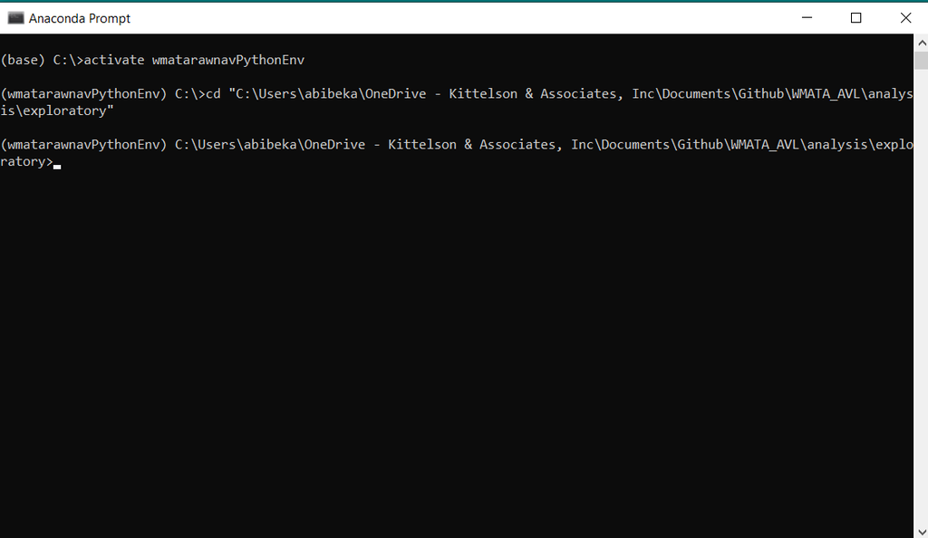

1. Run the following command: jupyter nbconvert --to html_toc 03_Compare_rawnav_to_field_data.ipynb

[figure not shown]